# Assumptions, Significance, and Effect Size

Kristopher Kyle

2/1/2019

## Some preliminary concepts in statistics

### Mean, median, and mode

**mean** The mean is what the general population refers to as the “average” score. To get the mean, we divide the number of observed values by the number of observations.

**median** The median is the middle observed values (when all values are arranged in ascending/descending order).

**mode** The mode is the observed value that occurs most often.

### Variance and standard deviation

__ population variance__ The variance in a set of observed values indicate how these values are distributed. To calculate the variance, we first subtract the mean from each of our observed values and square each of these values. We then calculate the mean for the squared values.

**population standard deviation** The standard deviation is the square root of the variance.

**sample variance** When we calculate the variance for a sample, we need to account for the fact that smaller samples will not perfectly reflect the population. In this case, when we calculate the mean for the squared values, we have to subtract one from the denominator. In small samples, this will have a large effect, but in large samples, the difference will be minimal.

**sample standard deviation** The sample standard deviation is simply the square root of the sample variance.

#### Calcuating descriptive statistics in R

```r
fundata <- read.csv("data/ICNALE_500_simple.csv", header = TRUE)
mean(fundata$VST) #mean VST score
```

```
## [1] 32.562
```

```r
median(fundata$VST) #median VST score
```

```
## [1] 33
```

```r
mode(fundata$VST) #mode
```

```
## [1] "numeric"
```

```r
var(fundata$VST) #variance in VST scores - by default this is the sample variance
```

```
## [1] 94.65146
```

```r
sd(fundata$VST) #standard deviation of VST scores - be default this is the sample standard deviation
```

```
## [1] 9.728898
```

### Checking assumptions: Normality

Many statistical tests require data that is normally distributed. These statistical tests are referred to as “parametric” statistical tests. Below, we will see how to to determine the degree to which our data is normally distributed both visually and statistically.

In a normal distribution, the median and the mean values will be the same, and ~68% of the data points will be within one standard deviation of the mean. The figure below shows the shape of a normal distribution.

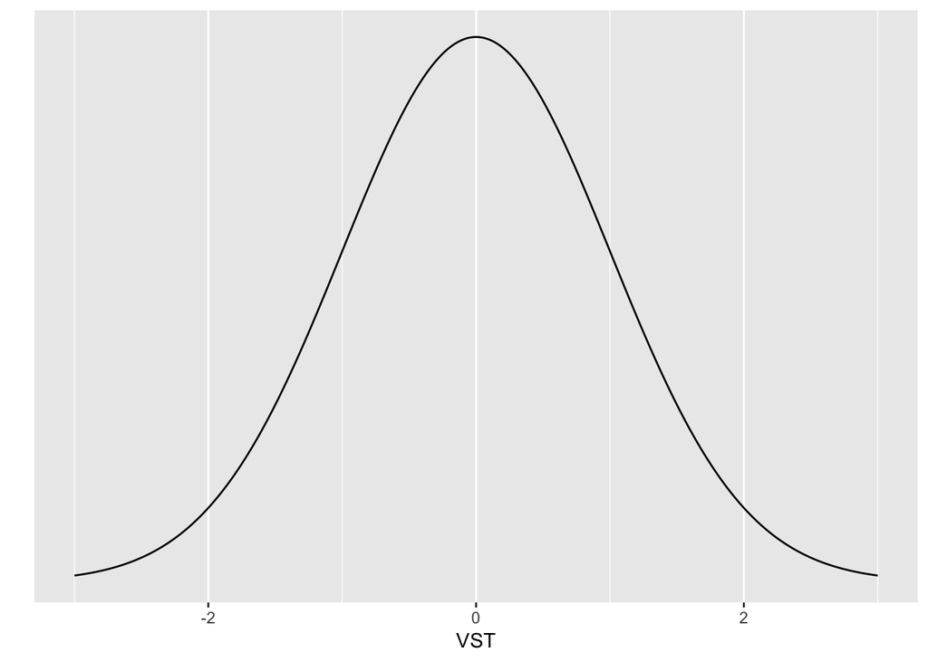

```r
library(ggplot2)
ggplot(data = data.frame(x = c(-3, 3)), aes(x)) +
  stat_function(fun = dnorm, n = 500, args = list(mean = 0, sd = 1)) + ylab("") + xlab("VST") +
  scale_y_continuous(breaks = NULL)
```

One way that we can check the degree to which our data is normally distributed is to check whether its distribution is similar to a perfectly normal distribution.

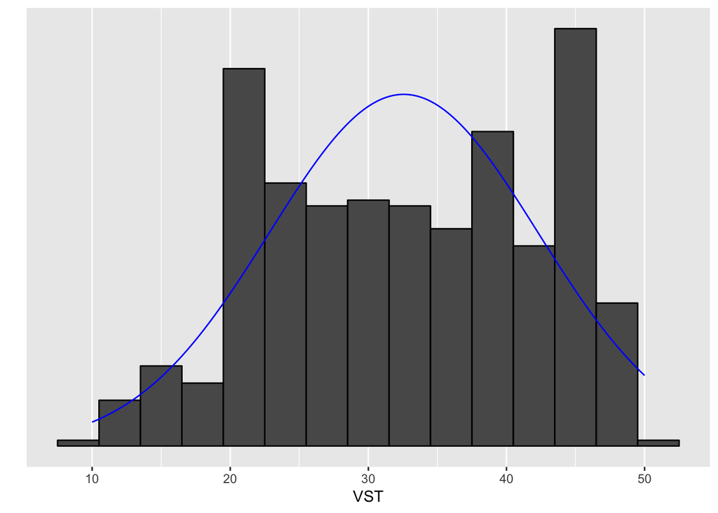

```r
ggplot(fundata, aes(x=VST)) +
  geom_histogram(aes(y=..density..), color = "black", binwidth = 3) +
  stat_function(fun = dnorm, n = 500, args = list(mean = mean(fundata$VST), sd = sd(fundata$VST)), color = "blue") +
  ylab("") +
  xlab("VST") +
  scale_y_continuous(breaks = NULL)
```

It appears as though our data is not normally distributed (it doesn’t look very much like the theoretical curve above).

Another way we can visually check our distribution is to use qq plots. If our data is normally distributed, then our actual data points will fall along our theoretical line (see plot below).

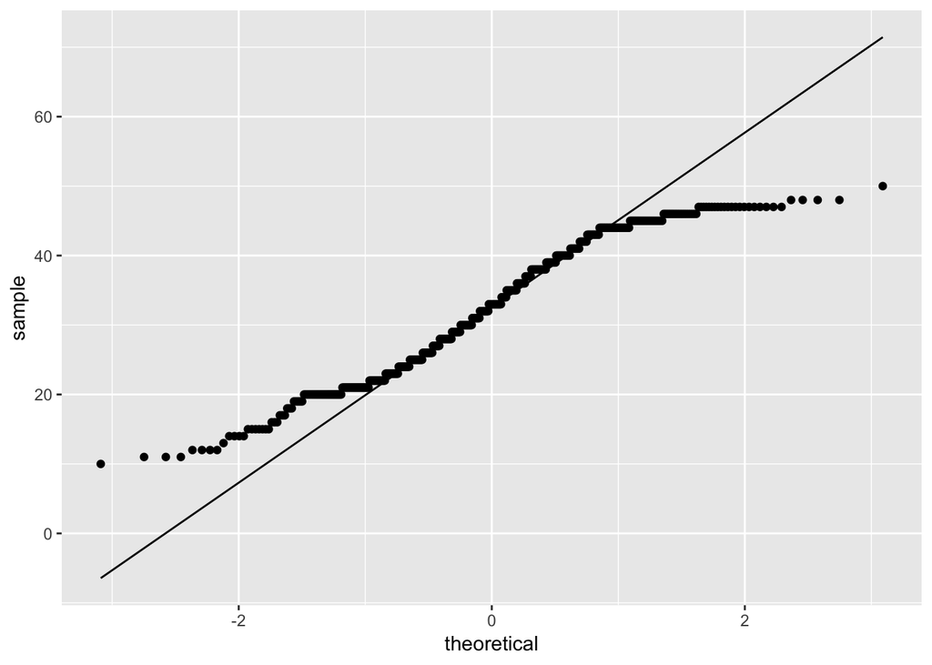

```r
ggplot(fundata, (aes(sample=VST))) + #note that the sample is the variable we are examinining
  stat_qq() + #this adds the points
  stat_qq_line() #this adds the theoretical line
```

In this case, we see that many of our observed data points fall above or below the theoretical line. This is further indication that our data is not normally distributed

However, we can also test to see the degree to which the observed distribution differs from the theoretical one using the Shapiro-Wilk test. In this case, if the *p* value is small (e.g., below .05), then we can assume that our observed distribution significantly differs from a normal distribution (i.e., it is not normal).

```r
shapiro.test(fundata$VST)
```

```
##
##  Shapiro-Wilk normality test
##
## data:  fundata$VST
## W = 0.95537, p-value = 3.717e-11
```

As we can see from the output, the VST scores are not normally distributed, indicating that we should not use parametric statistics using these values. Fortunately, there are a number of non-parametric tests that can be used (more on this later).

### More assumptions

Each statistical test has a variety of assumptions. As we learn about different tests, we will learn about these assumptions (and what to do if our data violates them).

## Significance and Effect Size

### Probability and Statistical Significance

Statistical significance is inherently tied to probability. In this course we will talk about a number of (relatively) complicated methods for determining the probability of observing a particular result, but in this tutorial we will keep things reasonably simple. In real research, for example, we might want to know whether the probability that a difference in vocabulary test scores between two populations are random or may possibibly be meaningful (e.g., one population had better instruction than the other). We will get to that issue soon enough, but for now we are going to examine a simpler issue. Given a particular population (lets say a group of intermediate language learners at a particular institution), what is the probability that a student will earn a particular score?

Let us assume for a moment that the scores are normally distributed with a range from 30 to 50, a mean of 40, and a standard deviation of 3.

```r
library(dplyr)
```

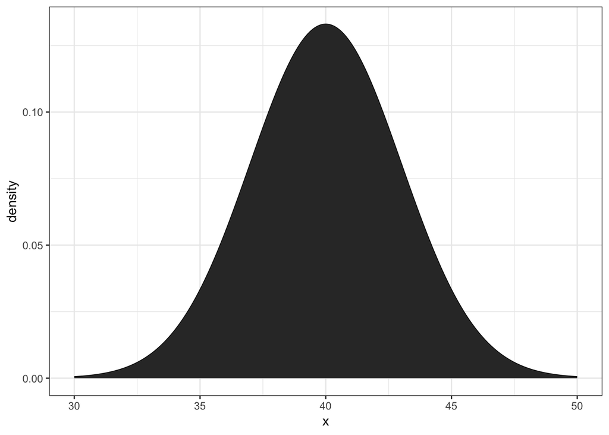

```r
library(ggplot2)
distr <- data.frame(x=seq(30, 50, length=300)) %>%
  mutate( density = dnorm(x, mean=40, sd=3))

ggplot(distr, aes(x=x, y=density)) +
  geom_line() +
  geom_area() +
  theme_bw()
```

Now, lets say that we have a student (Student A) who earns a score of 34 on the test. By looking at a density plot, we can see that only a very small proportion of students who scored lower than Student A and a large proportion of students who scored higher.

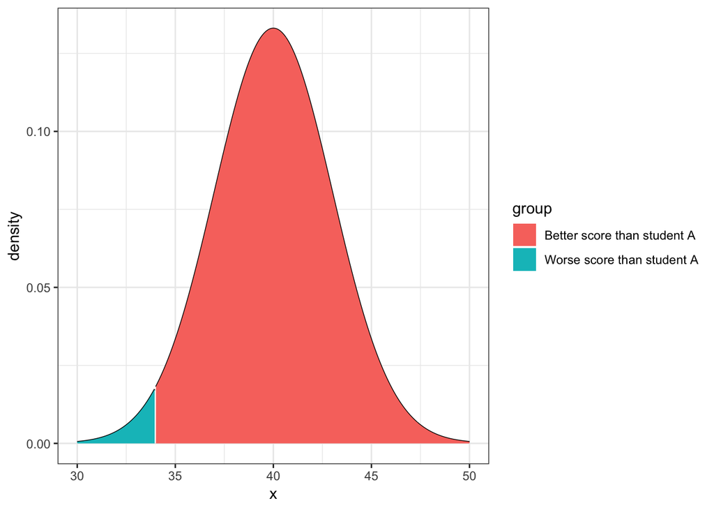

```r
distr <- data.frame(x=seq(30, 50, length=300)) %>%
  mutate(density = dnorm(x, mean=40, sd=3),
          group = ifelse(x<=34, 'Worse score than student A','Better score than student A'))

ggplot(distr, aes(x=x, y=density, fill=group)) +
  geom_line() +
  geom_area() +
  theme_bw()
```

To check this proportion precisely, we can use the pnorm() function.

```r
pnorm(34, mean = 40, sd = 3)
```

```
## [1] 0.02275013
```

The pnorm() function indicates that 2.275% of students (.02275) scored lower than Student A. Conversely, this means that 97.72% (0.9772) students scored higher than Student A.

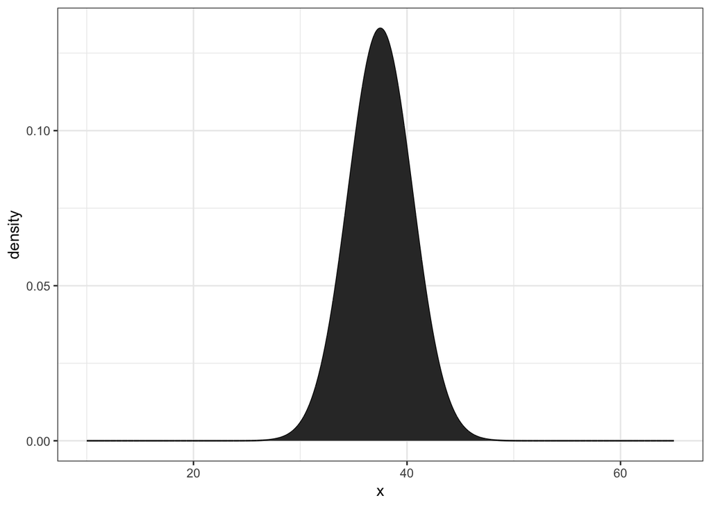

```r
distr <- data.frame(x=seq(10, 65, length=10000)) %>%
  mutate( density = dnorm(x, mean=37.5, sd=3))

ggplot(distr, aes(x=x, y=density)) +
  geom_line() +
  geom_area() +
  theme_bw()
```

One question we might ask is whether our students (with a mean score of 40) are on average significantly better than other groups of students. We plot this below:

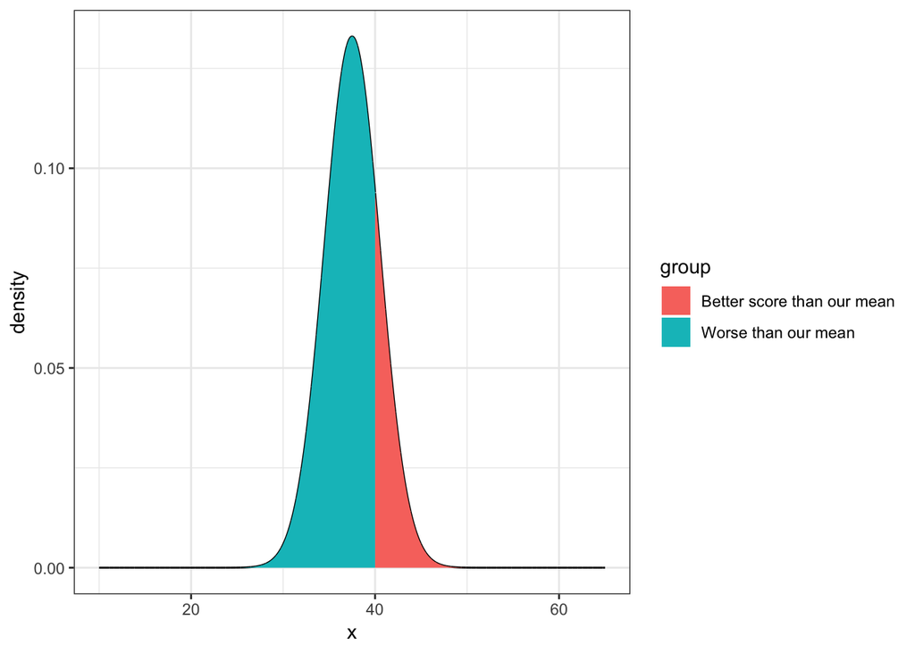

```r
distr <- data.frame(x=seq(10, 65, length=10000)) %>%
  mutate(density = dnorm(x, mean=37.5, sd=3),
  group = ifelse(x<=40, 'Worse than our mean','Better score than our mean'))

ggplot(distr, aes(x=x, y=density, fill=group)) +
  geom_line() +
  geom_area() +
  theme_bw()
```

```r
pnorm(40, mean = 37.5, sd = 3)
```

```
## [1] 0.7976716
```

The results indicate that our group of students get better scores than approximately 80% of the population, but 20% of the students get higher scores. So, if we took a random sample from the population of test scores, there is a 20% chance that the score would be higher than our mean.

If we were to ask whether our mean course scores are statistically significantly larger than the average for the population, the answer would be… it depends. In the social sciences, we generally set the significance level (also called an “alpha” level) at *p* = .05. This means that for an observed result to be significantly different from the population, it needs to be more extreme than 95% (.95) of population results.

We can check the score we would need to achieve to hit a certain probability threshold by using the qnorm() function.

```r
qnorm(.95, mean = 37.5, sd = 3)
```

```
## [1] 42.43456
```

So, in order for our scores to be considered significantly better than the population, we would need to have an average score of 42.43.

There are many caveats and more complicated situations that we will tackle when we look at each test covered in this course. Stay tuned.